# Wearable technologies and biosignals for user studies [PS0000022]

Introduction

[**Luca Menghini, Ph.D.**](https://scholar.google.it/citations?user=ZFRn4ssAAAAJ&hl=it&oi=ao)

***  
Master degree in  
COGNITIVE SCIENCE FOR HUMAN-CENTRIC TECHNOLOGIES  
University of Padova

**TAP THE RIGHT ARROW (→) TO NAVIGATE**

# Course structure and contents

## About the teacher

**Luca Menghini**

W/O Psychologist,  
Assistant Professor  
University of Padova, Italy

[figure not shown]

[figure not shown]

[figure not shown]

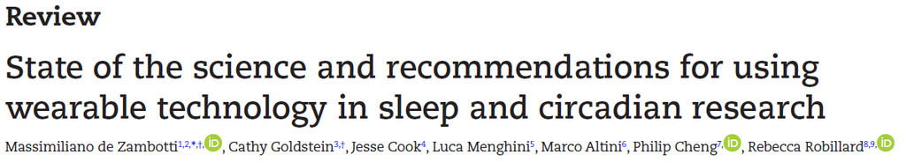

[figure not shown]

[figure not shown]

**Contacts**  
Forum: `Questions & Discussion` on Moodle  
Email: `luca.menghini@unipd.it`  
Office hours: Wednesday 15:30 - 17:30 (link on Moodle)

## About you

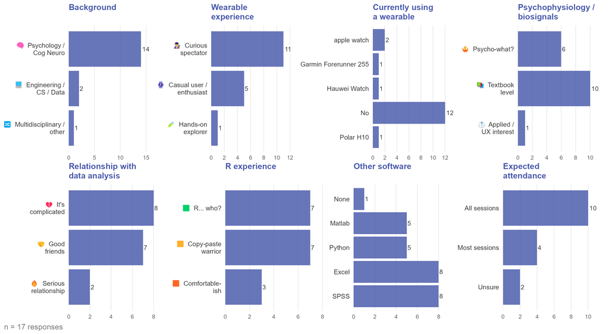

## About your expectations

(OPTIONAL) Is there anything specific you absolutely hope to take away from this small group activity?

> The ability to understand and/or design the key experimental phases in the field of wearable technologies through practical activities.

> I would like to take away Engineering concepts which can bridge the gap between my psychology knowledge and computer interaction.

> Learning more about the technology behind wearable biosignals

> understand what are the practical possible uses of this knowledge

> I am super interested in ethical and privacy issues about everyday wearable technologies, as well as the way of using the results gatherd by them for different purposes (e.g. for marketing purposes). I have never even thought about the way the smartwatch collects information about us (nor which information does it collect). However, I would also like to think of some ways these technologies could be used in an useful way in everyday life. (and of course, ‘behind the scenes’ of it all, that is the mechanism behind collecting the bio signals).

## About the course

20-hour (2 ECTS) Small Group Activity delivered in **blended format**

💻 **Part 1 online (10h)**

`1.1.` `What happens in the body?`  
Stress responses and biosignals in user studies

`1.2.` `How can we measure it?`  
Introduction to wearable tech

🏫 **Part 2 in person (10h)**

`2.` `Hands on wearables and biosignals`  
Practical activities & group project

## 💻 Part 1: theory, methods, & applications

`Stress responses and biosignals in user studies`

1. The stress response and the autonomic nervous system
2. Stress, cognitive appraisals, and recovery
3. Biosignals and biomarkers of stress and recovery

`Introduction to wearable technologies`

4. Wearable Technologies: Principles, Types and Applications
5. ECG & PPG for measuring heart rate and HRV
6. Electrodermal activity
7. Accelerometry & actigraphy for measuring activity and sleep
8. Can we trust wearable sensors? Validity, artefacts, ethics, and privacy

## 🏫 Part 2: hands-on activities & group project

5 in-person sessions with practical activities + group project

Participation in the in-person practical sessions is expected, as most of the group project  
and hands-on activities will be carried out during class.  
You are free to use your own laptop or the computers available in the room.

## Course program

💻 **Part 1 (online)**: 8 video lectures with slides and interactive activities to be completed on Moodle

| Week | Date | Video lectures |
| --- | --- | --- |
| 1 | October 28-30 | 1-2 |
| 2 | November 2-6 | 3-4 |
| 3 | November 9-13 | 5-6 |
| 4 | November 16-20 | 7-8 |

LIVE🔴 **Synchronous session (online)**  
October 30, 10:30 CEST, link on Moodle

🏫 **Part 2 (in person)**: 5 meetings in room 4N, “Psico 2” buidling, Via Venezia 12, Padova, 10:30-12:30 CEST

| Week | Date | Activity |
| --- | --- | --- |
| 5 | Friday, November 20 | 1 |
| 6 | Friday, November 27 | 2 |
| 7 | Friday, December 4 | 3 |
| 8 | Friday, December 11 | 4 |
| 9 | Friday, December 18 | 5 |

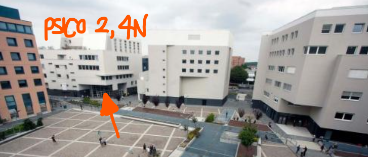

## Course material

Course material is available on Moodle:

> psico.elearning.unipd.it/course/view.php?id=6998
- Slides and video lectures
- Interactive activities on lecture contents
- Research papers
- Datasets and scripts
- Additional materials

## Optional textbooks

The course material (interactive video-lectures, slides, articles, datasets, and other educational resources) will be available in English on the course Moodle platform, covering all the main course contents.

Yet the following **OPTIONAL** textbooks are recommended for those wishing to further explore the topics covered in the course:

- Stern, Ray, & Karen (2001). *Psychophysiological Recording* (2nd edition), Oxford: Oxford University Press
- Sazonov (2021). *Wearable Sensors: Fundamentals, Implementation and Applications* (2nd edition), London: Academic Press
- Mehl & Conner (2012). *Handbook of Research Methods for Studying Daily Life*, New York: Guildford Press

## Target skills and knowledge

1. Understand the stress response and related cognitive constructs
2. Know and critically evaluate the main types of wearable sensors and associated biosignals
3. Analyze and critically evaluate applications of wearable tech in user studies
4. Design and implement user study protocols using wearable technologies
5. Apply pre-processing, visualization, and analysis techniques to biosignals

## Evaluation and assessment criteria

There is no final exam. The course is assessed on a pass/fail basis based on the **assignments completed throughout the course**, including Moodle activities, hands-on data analysis exercises, and the **group project** developed during the practical sessions.

The group project will consist of designing a **wearable-based user study**, from the formulation of research questions to the definition of the user study, data pre-processing strategy, and analysis and visualization plan. The projects will be presented during the final meeting.

Across the course activities, students will be required to demonstrate their ability to:

- Design data acquisition protocols using wearable technologies
- Pre-process and analyze biosignals using R
- Critically interpret physiological and behavioural data
- Plan appropriate data analyses and visualizations
- Effectively communicate methodological choices and results

# Introduction

## Wearable tech & biosignals

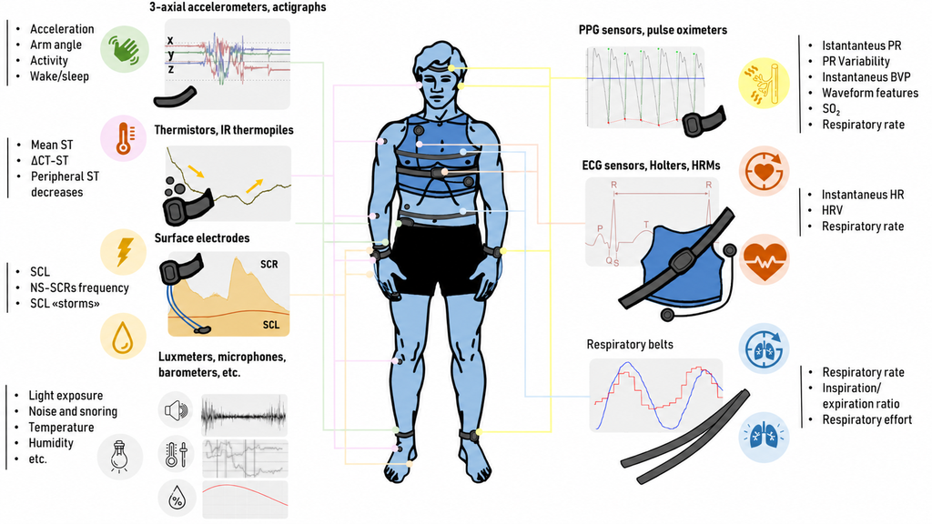

Adapted from de Zambotti, M., Cellini, N., Menghini, L., Sarlo, M., & Baker, F. C. (2020). Sensors capabilities, performance,  
and use of consumer sleep technology. Sleep medicine clinics, 15(1), 1-30. https://doi.org/10.1016/j.jsmc.2019.11.003

## Wearable tech & biosignals

Let’s see some examples

LIVE🔴

## Wearable tech & biosignals *for user studies*

A **wearable-based user study** uses body-worn sensors to collect physiological and behavioural data while people interact with technologies, systems, or other people through technology

- **User interaction**
- **Psychological construct**
- **Biosignal / behaviour**
- **Interpretation in context**

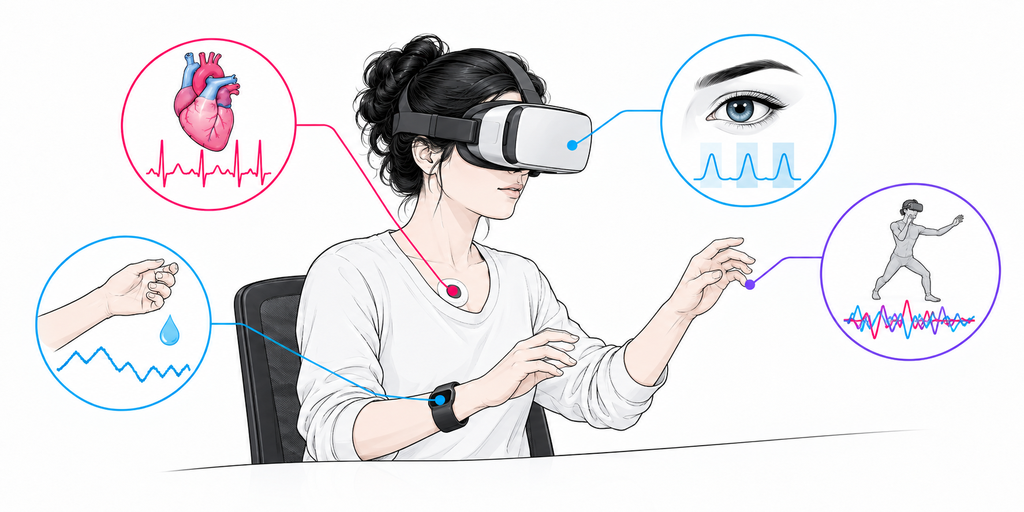

The goal is not to “detect stress”, but to understand  
how users respond to an interaction

## Two broad families of user studies

### 👤📱 Human–Tech Interaction

The user interacts directly with a technological system:

- using a mobile app
- navigation alert
- interacting with a chatbot
- working with a cobot
- using a VR environment

### 👤📱👤 Tech-Mediated Interaction

Technology mediates interaction between people:

- remote collaboration
- video calls
- expert–novice interaction
- online teamwork
- *e*-learning

## What psychophysiological data can add

They can help us study aspects of user experience that are difficult to capture with self-report and behavioral data alone:

- Arousal and activation
- Effort and workload
- Recovery after the interaction
- Task-related temporal dynamics
- Individual differences in  
  response patterns

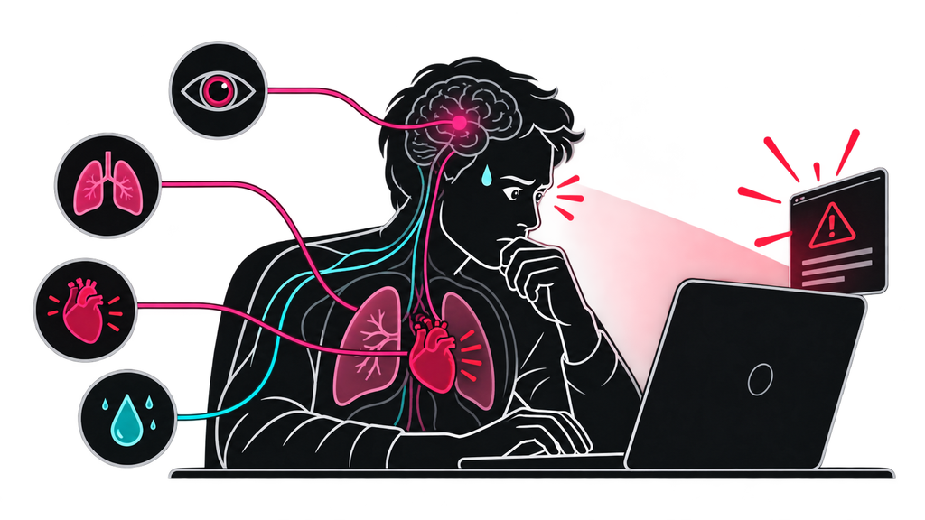

**But physiological data are meaningful only when interpreted together with task features, behaviour, and subjective experience**

## Common misconceptions

> *A wearable can measure stress directly*

**No.** Wearables record biosignals, not psychological constructs

> *If heart rate increases, the user is stressed*

**Not necessarily.** Heart rate may increase because of movement,  
posture, caffeine, or many other **confounding factors**

> *More biosignals and indices means better interpretation*

**Not necessarily.** Poorly contextualized biosignals can easily lead to  
overinterpretation and cherry picking 🍒

## From biosignals to interpretation

[figure not shown]

Wearable-based user studies requires a clear chain of reasoning:

- 👤 **What is the user doing?**
- 💡 **What construct are we interested in?**
- ⚡ **Which biosignals could reflect relevant processes?**
- ⌚ **Which sensor can measure it in this context?**
- 💥 **What could confound the interpretation?**

## Interactive activity on Wooclap

Anonymous answer (max 1 word)  
on wooclap.com

code: KIKBUCP

For each of the following scenarios, discuss:

1. 💡 **What construct would you study?**
2. ⚡ **What biosignal might be useful?**
3. ⌚ **What wearable device could you use?**
4. 💥 **What could confound the interpretation?**

### Scenario 1 - Health chatbot 🤖💬

A user interacts with a chatbot that asks questions about health behaviours and gives personalised feedback

Some questions are neutral, others more sensitive

## Interactive activity on Wooclap

Anonymous answer (max 1 word)  
on wooclap.com

code: KIKBUCP

For each of the following scenarios, discuss:

1. 💡 **What construct would you study?**
2. ⚡ **What biosignal might be useful?**
3. ⌚ **What wearable device could you use?**
4. 💥 **What could confound the interpretation?**

### Scenario 2 - Videoconference task 👤💻👤

A group of students completes a collaborative task in videoconference

Condition A: Camera on; Condition B: Camera off

## Interactive activity on Wooclap

Anonymous answer (max 1 word)  
on wooclap.com

code: KIKBUCP

For each of the following scenarios, discuss:

1. 💡 **What construct would you study?**
2. ⚡ **What biosignal might be useful?**
3. ⌚ **What wearable device could you use?**
4. 💥 **What could confound the interpretation?**

### Scenario 3 - Human–cobot collaboration 👤🦾

A user performs a manual task while a collaborative robot helps with part of the procedure

The robot can behave predictably or unexpectedly

## Any question?

## See you on Moodle!

> psico.elearning.unipd.it/course/view.php?id=6998

**Contacts**

Forum: `Questions & Discussion`

Email: luca.menghini@unipd.it

Office hours: Wednesday 15:30 - 17:30 (link on Moodle)

[figure not shown]